# ASS1

Tony Nguyen

February 8, 2019

Check directory:

```r
getwd()
```

```
## [1] "C:/Users/Dung/Dropbox/Stats/ASS1"
```

# Problem Number 1

Here is a breakdown of the grading process of course MATH4753.

The grading scale is standard. A is 90-100, B is 80-89, C is 70-79, D is 60-69, and F is under 50.

Work load of the course: - 4 Assignments (15% of grade) - Labs (10% of grade) - 2 Projects (10% of grade) - Clicker Quizzes (10% of grade) - Book Chapter Quizzes on Canvas (5% of grade) - 2 Midterms (20% of grade) - Final (30% of grade)

# Problem Number 2

```r
ddt = read.csv("DDT.csv")
head(ddt)
```

```
##   RIVER MILE  SPECIES LENGTH WEIGHT DDT
## 1   FCM    5 CCATFISH   42.5    732  10
## 2   FCM    5 CCATFISH   44.0    795  16
## 3   FCM    5 CCATFISH   41.5    547  23
## 4   FCM    5 CCATFISH   39.0    465  21
## 5   FCM    5 CCATFISH   50.5   1252  50
## 6   FCM    5 CCATFISH   52.0   1255 150
```

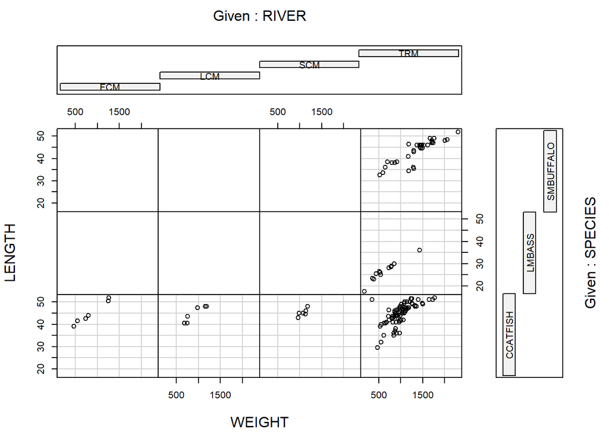

```r
# a) Plot of length vs weight given river and species.
coplot(LENGTH~WEIGHT|RIVER*SPECIES, number=3, data=ddt)
```

```r
# b) Interpret the lower left three conditional plots. The lower left three plots show the species of catfish in the FCM, LCM, and SCM rivers.

# c) What does line A do? Segmenting data from ddt and using factor of miles as a numeric value as a segmenting factor.
m = with(ddt, as.numeric(factor(MILE)))

# d) What does line B do? Line B takes only the unique values and gets the size of that.

# e) Why are the top six plots empty? They are empty because the rivers FCM, LCM, and SCM don't contain the species LMASS and SMBUFFALO.

# f) What is the mean value of DDT found in the sample of CCATFISH caught in the FCM river? The mean is 45.
fcm_catfish = ddt[ddt$RIVER=="FCM" & ddt$SPECIES=="CCATFISH",]
fcm_catfish_ddt = fcm_catfish$DDT
mean(fcm_catfish_ddt)
```

```
## [1] 45
```

# Problem Number 3

Problem 1.14 in the book about National Bridge Inventory. a) Length of max span (feet). Quantitative b) Number of vehicle lanes. Quantutative c) Toll bridge? (yes or no). Qualitative d) Average daily traffic. Quantitative e) Condition of deck (good, fair, poor). Qualitative f) Bypass or detour length (miles). Quantitative g) Route type (interstate, U.S state, county, city). Qualitative

# Problem Number 4

Read pages in the book about random sampling.

1. What are the names of the four random sampling designs (1 simple and 3 more complex). Simple random, stratified random, cluster, and systemic samplings.
2. Give a belief description of each. Simple random sampling is when we select items at random with no process. Stratified random sampling is when we can separate a population into two or more groups, called strata, and collect samples about those strata to form the overall sample. Cluster sampling is when we collect data from all units within a cluster. Systemic sampling is when we select a kth experimental unit from a population. For example, in a production line we can select every 50 items that pass through a certain area.

# Problem Number 5

Problem 1.15 in book. Groundwater contamination in wells.

```r
mtbe = read.csv("MTBE.csv", header = TRUE)
head(mtbe) # First six lines.
```

```
##     pH SpConduct DissOxy RoadsPct IndPct UrbanPct DevPct WellClass
## 1 7.87     290.0    0.58     1.34      0    17.77  17.77   Private
## 2 8.63     225.9    0.84     0.72      0    10.43  10.43   Private
## 3 7.11     157.4    8.37     1.92      0    29.62  50.01   Private
## 4 7.98     723.6    0.41     2.76      0    41.65  41.65   Private
## 5 7.88     148.7    1.44     3.51      0    51.21  51.21   Private
## 6 8.36     198.2    0.18     1.48      0    22.49  29.19   Private
##   Aquifier   Depth SafeYld Distance MTBE.Detect MTBE.Level HouseDen PopDen
## 1  Bedrock  60.960      NA  2386.29 Below Limit        0.2   131.16  43.19
## 2  Bedrock  36.576      NA  3667.69 Below Limit        0.2    47.69  24.52
## 3  Bedrock 152.400      NA  2324.15 Below Limit        0.2    85.16  33.32
## 4  Bedrock      NA      NA   788.88 Below Limit        0.2   134.77  46.61
## 5  Bedrock  91.440      NA  1337.88 Below Limit        0.2   198.54  78.58
## 6  Bedrock 115.824      NA  2396.74 Below Limit        0.2   206.73  59.47
```

```r
dim(mtbe) # Rows and columns.
```

```
## [1] 223  16
```

```r
ind=sample(1:223,5,replace=FALSE) # Random indices.
mtbe[ind,]
```

```
##       pH SpConduct DissOxy RoadsPct IndPct UrbanPct DevPct WellClass
## 207 7.62     579.6    2.57     2.50   0.00    25.85  32.34    Public
## 111 6.10     188.2    0.74     0.70   3.52     5.40  14.01    Public
## 95  8.24     694.3    3.27     3.50   0.00    49.35  49.35   Private
## 215 5.85     741.7    5.29     3.72   0.00    52.79  56.03    Public
## 119 8.05     199.9    0.42     0.00   0.00     0.52   0.52    Public
##      Aquifier  Depth  SafeYld Distance MTBE.Detect MTBE.Level HouseDen
## 207   Bedrock 45.720       NA  1307.40      Detect       0.37   136.41
## 111 Unconsoli     NA 757.0023   804.76 Below Limit       0.20    53.03
## 95    Bedrock 91.440       NA  1711.46      Detect       0.39   174.77
## 215 Unconsoli  9.144       NA  1746.12      Detect       0.33   217.39
## 119   Bedrock 80.772 246.0257  1049.97 Below Limit       0.20    37.92
##     PopDen
## 207   0.00
## 111  22.27
## 95   85.67
## 215  84.15
## 119  13.97
```

```r
# Omitting na from data frame.
mtbeo = na.omit(mtbe)

# Standard deviation of the depths of Bedrock well.
depth = mtbeo[mtbeo$Aquifier=="Bedrock",]$Depth
sd(depth)
```

```
## [1] 56.45357
```

# Problem Number 6

Problem 1.16 in the book. Earthquakes.

```r
eq = read.csv("EARTHQUAKE.csv")

v = sample(1:223, 5, replace=FALSE)
eq[v,]
```

```
##     YEAR MONTH DAY HOUR MINUTE MAGNITUDE
## 191 1994     1  18    0      6       3.1
## 9   1994     1  17   12     40       4.3
## 204 1994     1  18    1     38       3.0
## 139 1994     1  17   20      5       3.8
## 62  1994     1  17   14     37       3.0
```

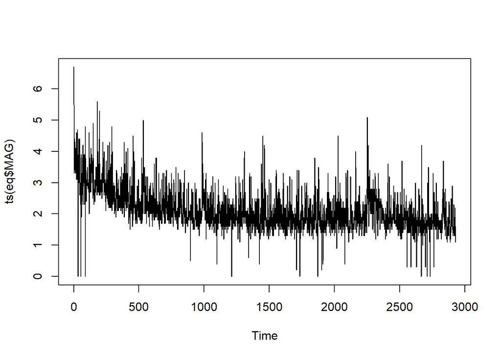

```r
# Plot
plot(ts(eq$MAG))
```

```r
# Median of median of magnitude.
median(median(eq$MAGNITUDE))
```

```
## [1] 2
```

# Problem Number 7

Read the story on page 18.

1. What is the data collection method? The experiment was a designed experiment using stratified sample method.
2. What is the population? Fishes and different species of them.
3. What are the qualitative variables? Location and species of the fish.

# Problem Number 8

Page 2.1 Do social robots walk or roll? a) What type of graph is used to describe the data? A bar graph with frequencies. b) Identify the variable measured for each of the 106 robot designs. Variables: Legs only, wheels only, both legs and wheels, or none. c) Use the graph to identify the social robot design that is currently used the most. According to the graph, social robots built with legs only is the design used the most. d) Compute class relative frequencies for the different categories shown in the graph. None - 15, Both - 8, Legs - 63, Wheels - 20. e) Make a Pareto diagram.

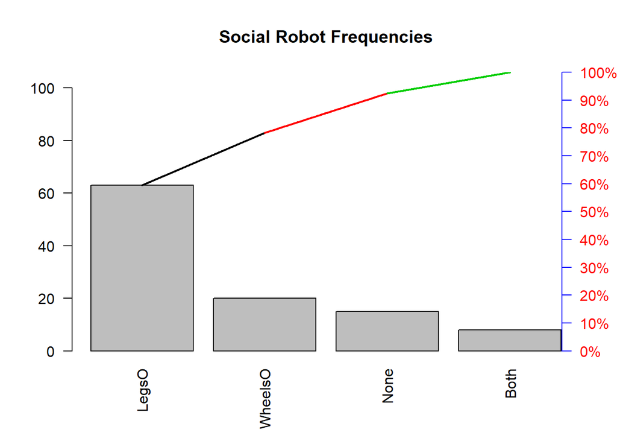

```r
freq = c(15,8,63,20)
RL = c("None","Both","LegsO","WheelsO")
l = rep(RL,freq)

# Pareto function from Dr. Stewart.
pareto<-function(x,mn="Pareto barplot",...){  # x is a vector
x.tab=table(x)
xx.tab=sort(x.tab, decreasing=TRUE,index.return=FALSE)
cumsum(as.vector(xx.tab))->cs
length(x.tab)->lenx
bp<-barplot(xx.tab,ylim=c(0,max(cs)),las=2)
lb<-seq(0,cs[lenx],l=11)
axis(side=4,at=lb,labels=paste(seq(0,100,length=11),"%",sep=""),las=1,line=-1,col="Blue",col.axis="Red")
for(i in 1:(lenx-1)){
segments(bp[i],cs[i],bp[i+1],cs[i+1],col=i,lwd=2)
}
title(main=mn,...)

}

pareto(l, "Social Robot Frequencies")
```

# Problem Number 9

Book problem 2.4 page 27.

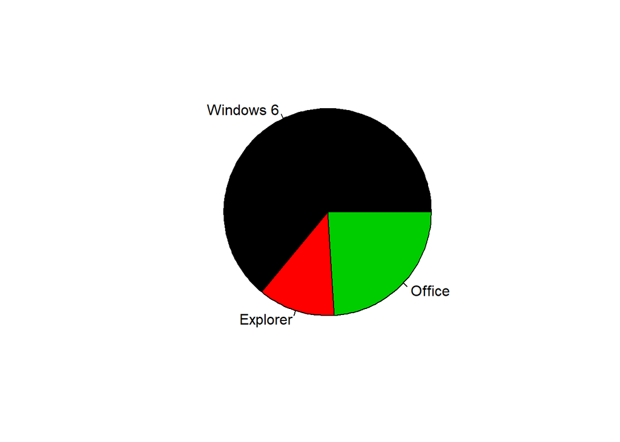

```r
securityFreq = c(32,6,12)
RL1 = c("Windows 6","Explorer","Office")
l1 = rep(RL1,securityFreq)
names(securityFreq) <- RL1

# a) Make a pie chart of the three products. Looking at the pie chart below, it shows that Explorer had the least amount of security issues.
pie(securityFreq, col=1:4)
```

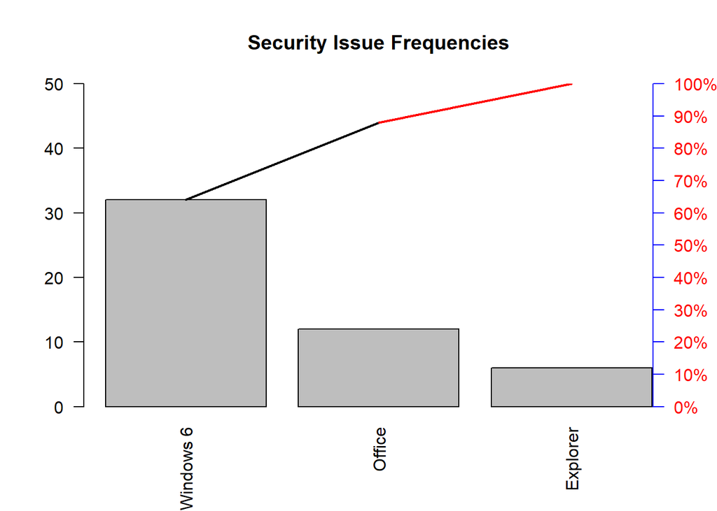

```r
# b) Make a pareto function.
pareto(l1, "Security Issue Frequencies")
```

# Problem Number 10

Book problem 2.10.

```r
swd = read.csv("SWDEFECTS.csv")
head(swd)
```

```
##   Mloc Mvg Mevg Mivg   Hn  Hvol Hpgmlen Hdiff Hintell Heffort   Hb Htime
## 1  1.1 1.4  1.4  1.4  1.3   1.3    1.30  1.30    1.30       1 1.30     1
## 2  1.0 1.0  1.0  1.0  1.0   1.0    1.00  1.00    1.00       1 1.00     1
## 3 24.0 5.0  1.0  3.0 63.0 309.1    0.11  9.50   32.54    2937 0.10   163
## 4 20.0 4.0  4.0  2.0 47.0 215.5    0.06 16.00   13.47    3448 0.07   192
## 5 24.0 6.0  6.0  2.0 72.0 346.1    0.06 17.33   19.97    6000 0.12   333
## 6 24.0 6.0  6.0  2.0 72.0 346.1    0.06 17.33   19.97    6000 0.12   333
##   Hloc Hcomm Hblank loc.comm uniOp uniOpnd totOp totOpnd brnchcnt defect
## 1    2     2      2        2   1.2     1.2   1.2     1.2      1.4  FALSE
## 2    1     1      1        1   1.0     1.0   1.0     1.0      1.0   TRUE
## 3    1     0      6        0  15.0    15.0  44.0    19.0      9.0  FALSE
## 4    0     0      3        0  16.0     8.0  31.0    16.0      7.0  FALSE
## 5    0     0      3        0  16.0    12.0  46.0    26.0     11.0  FALSE
## 6    0     0      3        0  16.0    12.0  46.0    26.0     11.0  FALSE
##   predict.vg.10 predict.evg.14.5 predict.ivg.9.2 predict.loc.50
## 1            no               no              no             no
## 2            no               no              no             no
## 3            no               no              no             no
## 4            no               no              no             no
## 5            no               no              no             no
## 6            no               no              no             no
```

```r
library(plotrix)
tab = table(swd$defect)
rtab = tab/sum(tab)
round(rtab, 2)
```

```
##
## FALSE  TRUE
##   0.9   0.1
```

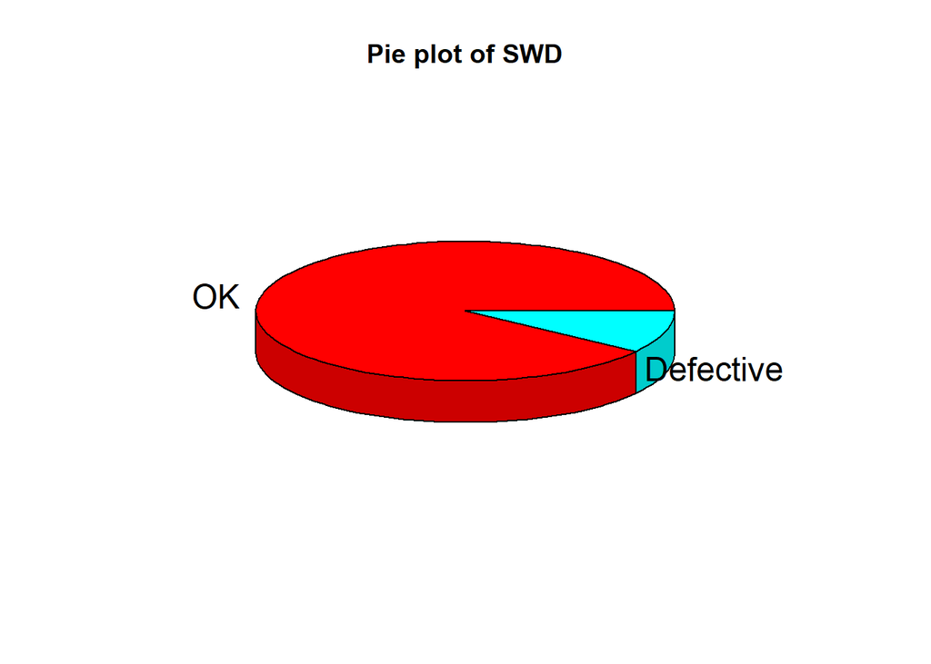

```r
pie3D(rtab, labels = list("OK", "Defective"), main = "Pie plot of SWD")
```

# Problem Number 11

Book problem 2.72 page 70.

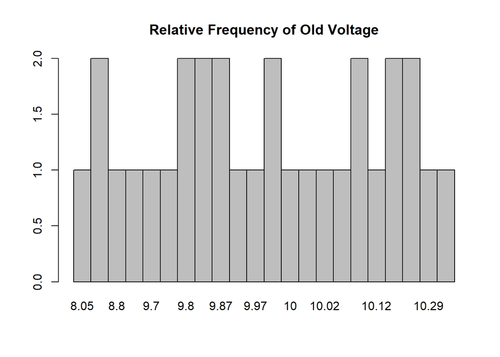

```r
# a) Constructing histogram for old voltage.
voltage = read.csv("VOLTAGE.csv")
oldData = subset(voltage, subset = LOCATION=="OLD")
oldDataTable = with(oldData,table(VOLTAGE))
barplot(oldDataTable, space = 0, main = "Relative Frequency of Old Voltage")
```

```r
# b) Make a stem plot of old voltage.
stem(oldDataTable)
```

```
##
##   The decimal point is at the |
##
##   1 | 00000000000000
##   1 |
##   2 | 00000000
```

```r
# c) Now make a histogram of the new voltage.
new=subset(voltage,subset=LOCATION=="NEW")
new$VOLTAGE->vtn
vtn
```

```
##  [1]  9.19  9.63 10.10  9.70 10.09  9.60 10.05 10.12  9.49  9.37 10.01
## [12]  8.82  9.43 10.03  9.85  9.27  8.83  9.39  9.48  9.64  8.82  8.65
## [23]  8.51  9.14  9.75  8.78  9.35  9.54  9.36  8.68
```

```r
max(vtn)
```

```
## [1] 10.12
```

```r
min(vtn)
```

```
## [1] 8.51
```

```r
lept<-min(vtn)-0.05
rept<-max(vtn)+0.05
rnge<-rept-lept
inc<-rnge/9
inc
```

```
## [1] 0.19
```

```r
seq(lept, rept,by=inc)->cl
cl
```

```
##  [1]  8.46  8.65  8.84  9.03  9.22  9.41  9.60  9.79  9.98 10.17
```

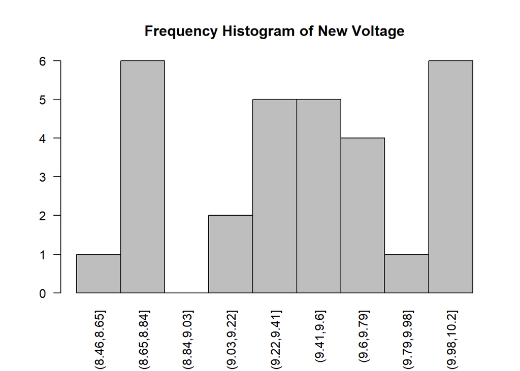

```r
cvtn<-cut(vtn,breaks=cl)
new.tab=table(cvtn)
barplot(new.tab,space=0,main="Frequency Histogram of New Voltage",las=2)
```

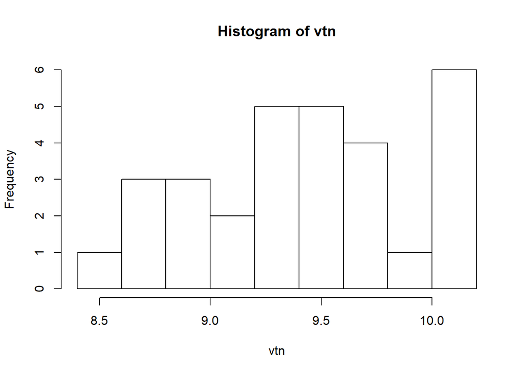

```r
hist(vtn,nclass=10)
```